# Tissue segmentation with U-Net 2D NN

```r
source("R/_common.R") # knitr setup
source("R/dicom_info.R")
source("R/dicom_plot.R")
```

```r
library(ANTsRCore)
library(ANTsR)
library(ANTsRNet)

library(keras)
source("R/multilabel_dice_coefficient_2d.R")
```

Set dimensions for cropped images and set the segmentation labels.

```r
domain_image <- ANTsRCore::makeImage(c(768, 384))
segmentation_labels = c(0, 1)
```

```r
number_of_labels <- length(segmentation_labels)
image_dimension <- length(dim(domain_image))     # 2
```

Set the `X_train` shape to:
$$\rm batch\_size \times width \times height \times \langle depth\rangle
=
8 \times 768 \times 384 \times 1$$
and the `Y_train` shape to:
$$8 \times 768 \times 384 \times 2$$

## Get the info about base images

These images will be cropped to the dimensions displayed above.

```r
info <- dicom_info("11_DICOM") %>%
  dplyr::filter(image == "base") %>%
  dplyr::filter(`x×y×z` != '1273×832×1') %>%
  dplyr::filter(image_id != 197310)
info
```

| series | image_id | image | x×y×z | pixel resolution [mm] | file_name |
| --- | --- | --- | --- | --- | --- |
| 11_DICOM | 151609 | base | 836×496×1 | 1×1×1 | 11_DICOM/151609/image_base/1.2.840.19104.20483.007.601003.1.637386428346688918.dcm |
| 11_DICOM | 158894 | base | 836×496×1 | 1×1×1 | 11_DICOM/158894/image_base/1.2.840.19104.20483.007.401003.1.637386430907564627.dcm |
| 11_DICOM | 161293 | base | 836×496×1 | 1×1×1 | 11_DICOM/161293/image_base/1.2.840.19104.20483.007.401003.1.637386434175706933.dcm |
| 11_DICOM | 197929 | base | 836×496×1 | 1×1×1 | 11_DICOM/197929/image_base/1.2.840.19104.20483.007.601003.1.637386438525965266.dcm |
| 11_DICOM | 211190 | base | 836×496×1 | 1×1×1 | 11_DICOM/211190/image_base/1.2.840.19104.20483.007.1201.1.637386451281488172.dcm |
| 11_DICOM | 216649 | base | 836×496×1 | 1×1×1 | 11_DICOM/216649/image_base/1.2.840.19104.20483.007.701003.1.637386452704344742.dcm |
| 11_DICOM | 254582 | base | 836×496×1 | 1×1×1 | 11_DICOM/254582/image_base/1.2.840.19104.20483.007.1201.1.637386453888752589.dcm |
| 11_DICOM | 281774 | base | 836×496×1 | 1×1×1 | 11_DICOM/281774/image_base/1.2.840.19104.20483.007.1201.1.637386455005178126.dcm |

## [Convolutional Neural Networks (ConvNets)](https://cs231n.github.io/convolutional-networks/)

*Convolutional Neural Networks* are very similar to ordinary *Neural Networks*: they are made up of neurons that have learnable weights and biases. Each neuron receives some inputs, performs a dot product and optionally follows it with a non-linearity.

So what changes? *ConvNet architectures make the explicit assumption that the inputs are images*, which allows us to encode certain properties into the architecture. These then make the forward function more efficient to implement and vastly reduce the amount of parameters in the network.

```r
training_batch_size <- dim(info)[1]
```

```r
X_train <- array(
  data = NA, dim = c(training_batch_size, dim(domain_image), 1)
)

Y_train <- array(
  data = NA, dim = c(training_batch_size, dim(domain_image))
)
```

```r
str(X_train)
```

```
#>  logi [1:8, 1:768, 1:384, 1] NA NA NA NA NA NA ...
```

```r
str(Y_train)
```

```
#>  logi [1:8, 1:768, 1:384] NA NA NA NA NA NA ...
```

## Plot all images needed by the U-Net

Here we check if the preprocessing step works.

```r
image_list = vector("list", length = training_batch_size)
mask_list = vector("list", length = training_batch_size)

iplot_list = vector("list", length = training_batch_size)
mplot_list = vector("list", length = training_batch_size)

for(i in seq_len(training_batch_size)) {
  image <- antsImageRead(info$file_name[i], 2)

  image_list[[i]] <- cropIndices(image, c(34, 56), c(801, 439))
  mask_list[[i]] <- getMask(image_list[[i]])
  image_list[[i]] <- image_list[[i]] * mask_list[[i]]

  iplot_list[[i]] <- plotColor(image_list[[i]])
  mplot_list[[i]] <- plotColor(mask_list[[i]])
}
```

### Base images

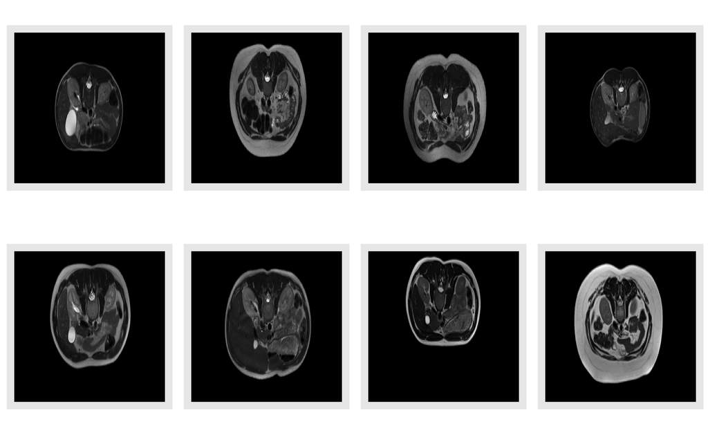

```r
cowplot::plot_grid(plotlist = iplot_list, ncol = 4)
```

### Tissue masks

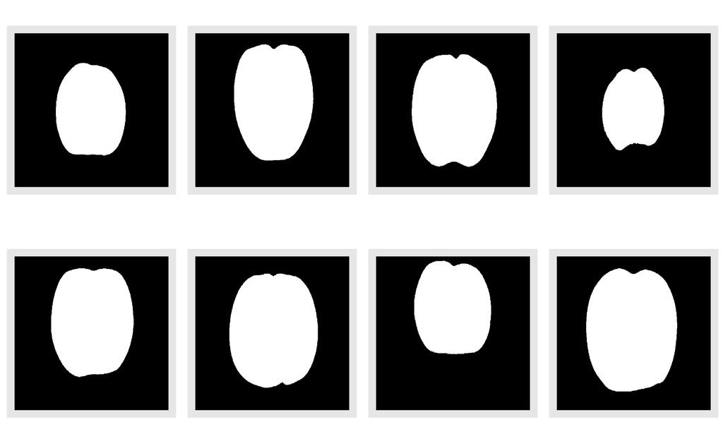

```r
cowplot::plot_grid(plotlist = mplot_list, ncol = 4)
```

## Read images into `X_train` tensor and tissue masks into `Y_train`

```r
for(i in seq_len(training_batch_size)) {
  X_train[i,,, 1] <- as.array(image_list[[i]])
  Y_train[i,, ] <- as.array(mask_list[[i]])
}

Y_train <- encodeUnet(Y_train, segmentation_labels)
```

```r
str(X_train)
```

```
#>  num [1:8, 1:768, 1:384, 1] 0 0 0 0 0 0 0 0 0 0 ...
```

```r
str(Y_train)
```

```
#>  num [1:8, 1:768, 1:384, 1:2] 1 1 1 1 1 1 1 1 1 1 ...
```

## U-Net encoded `Y_train` images

```r
channel1_list = vector("list", length = training_batch_size)
channel2_list = vector("list", length = training_batch_size)

plot1_list = vector("list", length = training_batch_size)
plot2_list = vector("list", length = training_batch_size)

for(i in seq_len(training_batch_size)) {
  channel1_list[[i]] <- as.antsImage(Y_train[i,,,1])
  channel2_list[[i]] <- as.antsImage(Y_train[i,,,2])
  plot1_list[[i]] <- plotColor(channel1_list[[i]])
  plot2_list[[i]] <- plotColor(channel2_list[[i]])
}
```

### 1st channel

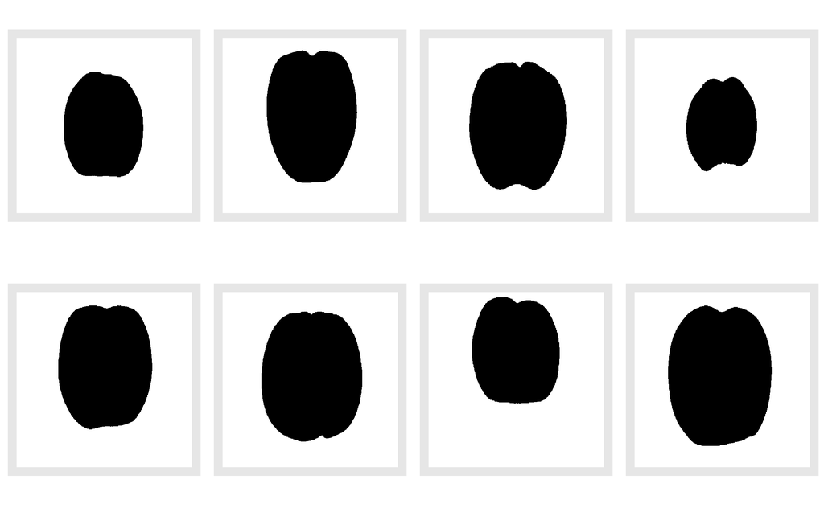

```r
cowplot::plot_grid(plotlist = plot1_list, ncol = 4)
```

### 2nd channel

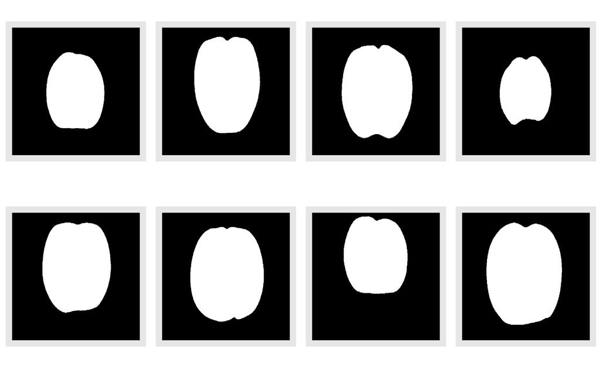

```r
cowplot::plot_grid(plotlist = plot2_list, ncol = 4)
```

## U-Net model for tissue segmentation

Set up model hyperparameters.

```r
number_of_layers <- 4
number_of_filters_at_base_layer <- 32
number_of_epochs <- 16
```

```r
model <- createUnetModel2D(
  inputImageSize = c(dim(domain_image), 1),
  numberOfOutputs = number_of_labels,
  numberOfLayers = number_of_layers,
  numberOfFiltersAtBaseLayer = number_of_filters_at_base_layer,
  # dropoutRate = 0.5,
  mode = "classification"
)
```

## U-Net Architecture

We can compute *the spatial size of the output volume* as a function of:

1. $W$ – the input volume size,
2. $F$ – the receptive field size of the Convolutional Layer neurons,
3. $P$ – the amount of zero padding used on the border
4. $S$ – the stride with which they are applied.

```r
output_volume_size <- function(W, F, P, S) {
  (W - F + 2 * P) / S + 1
}
output_volume_size(c(768, 384), c(3, 3), c(0,0), c(2, 2))
```

[output not shown]

## Layers used to build the U-Net model

```r
summary(model)
```

```
#> Model: "model"
#> ________________________________________________________________________________
#> Layer (type)              Output Shape      Param #  Connected to
#> ================================================================================
#> input_1 (InputLayer)      [(None, 768, 384, 0
#> ________________________________________________________________________________
#> conv2d (Conv2D)           (None, 768, 384,  320      input_1[0][0]
#> ________________________________________________________________________________
#> conv2d_1 (Conv2D)         (None, 768, 384,  9248     conv2d[0][0]
#> ________________________________________________________________________________
#> max_pooling2d (MaxPooling (None, 384, 192,  0        conv2d_1[0][0]
#> ________________________________________________________________________________
#> conv2d_2 (Conv2D)         (None, 384, 192,  18496    max_pooling2d[0][0]
#> ________________________________________________________________________________
#> conv2d_3 (Conv2D)         (None, 384, 192,  36928    conv2d_2[0][0]
#> ________________________________________________________________________________
#> max_pooling2d_1 (MaxPooli (None, 192, 96, 6 0        conv2d_3[0][0]
#> ________________________________________________________________________________
#> conv2d_4 (Conv2D)         (None, 192, 96, 1 73856    max_pooling2d_1[0][0]
#> ________________________________________________________________________________
#> conv2d_5 (Conv2D)         (None, 192, 96, 1 147584   conv2d_4[0][0]
#> ________________________________________________________________________________
#> max_pooling2d_2 (MaxPooli (None, 96, 48, 12 0        conv2d_5[0][0]
#> ________________________________________________________________________________
#> conv2d_6 (Conv2D)         (None, 96, 48, 25 295168   max_pooling2d_2[0][0]
#> ________________________________________________________________________________
#> conv2d_7 (Conv2D)         (None, 96, 48, 25 590080   conv2d_6[0][0]
#> ________________________________________________________________________________
#> conv2d_transpose (Conv2DT (None, 96, 48, 12 131200   conv2d_7[0][0]
#> ________________________________________________________________________________
#> up_sampling2d (UpSampling (None, 192, 96, 1 0        conv2d_transpose[0][0]
#> ________________________________________________________________________________
#> concatenate (Concatenate) (None, 192, 96, 2 0        up_sampling2d[0][0]
#>                                                      conv2d_5[0][0]
#> ________________________________________________________________________________
#> conv2d_8 (Conv2D)         (None, 192, 96, 1 295040   concatenate[0][0]
#> ________________________________________________________________________________
#> conv2d_9 (Conv2D)         (None, 192, 96, 1 147584   conv2d_8[0][0]
#> ________________________________________________________________________________
#> conv2d_transpose_1 (Conv2 (None, 192, 96, 6 32832    conv2d_9[0][0]
```

[output cut: 12 more lines]

```
#> up_sampling2d_2 (UpSampli (None, 768, 384,  0        conv2d_transpose_2[0][0]
#> ________________________________________________________________________________
#> concatenate_2 (Concatenat (None, 768, 384,  0        up_sampling2d_2[0][0]
#>                                                      conv2d_1[0][0]
#> ________________________________________________________________________________
#> conv2d_12 (Conv2D)        (None, 768, 384,  18464    concatenate_2[0][0]
#> ________________________________________________________________________________
#> conv2d_13 (Conv2D)        (None, 768, 384,  9248     conv2d_12[0][0]
#> ________________________________________________________________________________
#> conv2d_14 (Conv2D)        (None, 768, 384,  66       conv2d_13[0][0]
#> ================================================================================
#> Total params: 1,925,058
#> Trainable params: 1,925,058
#> Non-trainable params: 0
#> ________________________________________________________________________________
```

### Constraints on strides

Note again that the spatial arrangement hyperparameters have mutual constraints. For example, when the input has size $W=10$, zero-padding is used $P=0$, and the filter size is $F=3$, then it would be impossible to use stride $S=2$, since $(W−F+2P)/S+1=(10−3+0)/2+1=4.5$, i.e. not an integer, indicating that the neurons don’t “fit” neatly and symmetrically across the input. Therefore, this setting of the hyperparameters is considered to be invalid.

## U-Net Hyperparameters

1. number of layers
2. depth
3. stride

## Compile the model

```r
model %>% compile(
  loss = loss_dice,
  optimizer = optimizer_adam(lr = 0.0001),
  metrics = metric_multilabel_dice_coefficient_2d
)
```

```
#>
#> y_true: Tensor("conv2d_14_target:0", shape=(None, None, None, None), dtype=float32)
#> y_pred: Tensor("conv2d_14/Identity:0", shape=(None, 768, 384, 2), dtype=float32)
#>
#> y_true: Tensor("conv2d_14_target:0", shape=(None, None, None, None), dtype=float32)
#> y_pred: Tensor("conv2d_14/Identity:0", shape=(None, 768, 384, 2), dtype=float32)
```

## Run the model

```r
track <- model %>% keras::fit(
  X_train, Y_train,
  epochs = number_of_epochs,
  batch_size = 8, verbose = 1,
  shuffle = FALSE, # whether to shuffle the training data before each epoch
  callbacks = list(
    # callback_model_checkpoint(
    #   "unetModelInterimWeights.h5",
    #   monitor = 'val_loss',
    #   save_best_only = TRUE
    # ),
    callback_reduce_lr_on_plateau(
      monitor = "val_loss",
      factor = 0.1
    )
  ),
  validation_split = 0.25
)
```

```
#>
#> y_true: Tensor("IteratorGetNext:1", shape=(None, 768, 384, 2), dtype=float32)
#> y_pred: Tensor("model/conv2d_14/truediv:0", shape=(None, 768, 384, 2), dtype=float32)
#>
#> y_true: Tensor("IteratorGetNext:1", shape=(None, 768, 384, 2), dtype=float32)
#> y_pred: Tensor("model/conv2d_14/truediv:0", shape=(None, 768, 384, 2), dtype=float32)
#>
#> y_true: Tensor("IteratorGetNext:1", shape=(None, 768, 384, 2), dtype=float32)
#> y_pred: Tensor("model/conv2d_14/truediv:0", shape=(None, 768, 384, 2), dtype=float32)
#>
#> y_true: Tensor("IteratorGetNext:1", shape=(None, 768, 384, 2), dtype=float32)
#> y_pred: Tensor("model/conv2d_14/truediv:0", shape=(None, 768, 384, 2), dtype=float32)
#>
#> y_true: Tensor("IteratorGetNext:1", shape=(None, 768, 384, 2), dtype=float32)
#> y_pred: Tensor("model/conv2d_14/truediv:0", shape=(None, 768, 384, 2), dtype=float32)
#>
#> y_true: Tensor("IteratorGetNext:1", shape=(None, 768, 384, 2), dtype=float32)
#> y_pred: Tensor("model/conv2d_14/truediv:0", shape=(None, 768, 384, 2), dtype=float32)
```

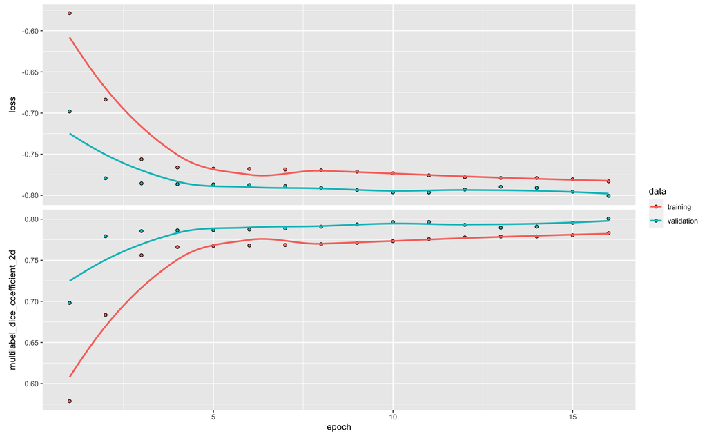

```r
plot(track)
```

```r
keras::save_model_hdf5(
  model,
  filepath = model_file_name(
    layers = number_of_layers,
    filters = number_of_filters_at_base_layer,
    epochs = number_of_epochs
  )
)
```

```r
dice_coeff <- function(union_overlap, smoothing_factor = 1) {
  (2 * union_overlap + smoothing_factor)/(1 + union_overlap + smoothing_factor)
}

union_overlap <- function(dice_coeff) {
  (2 * dice_coeff - 1) / (2 - dice_coeff)
}
```

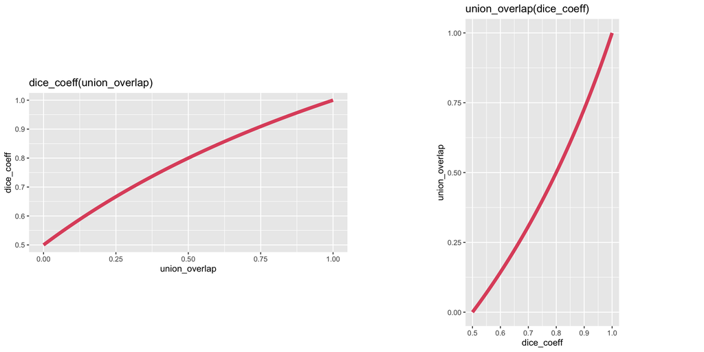

## All predictions

```r
Y_pred <- decodeUnet(model %>% predict(X_train), domain_image)
image_id = info$image_id

str(image_id)
```

```
#>  int [1:8] 151609 158894 161293 197929 211190 216649 254582 281774
```

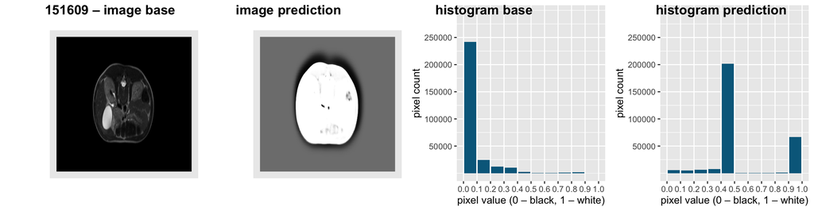

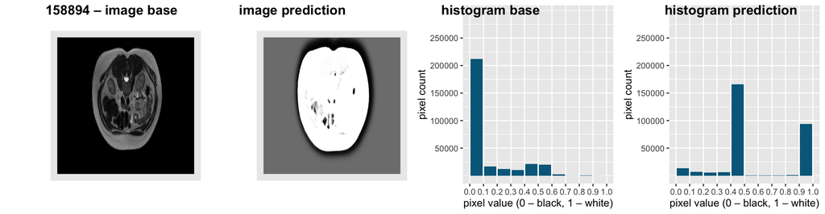

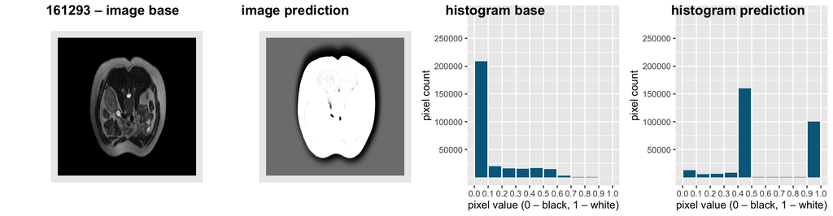

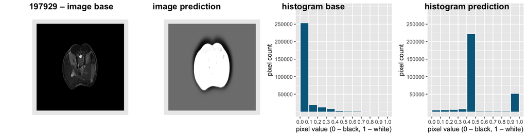

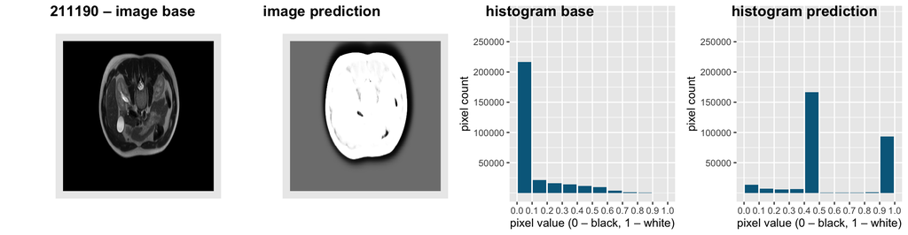

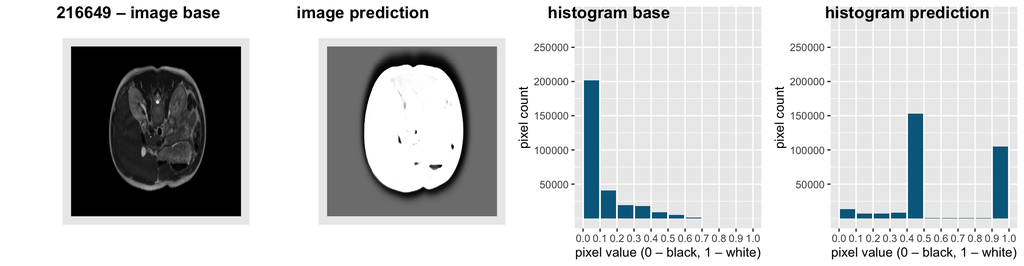

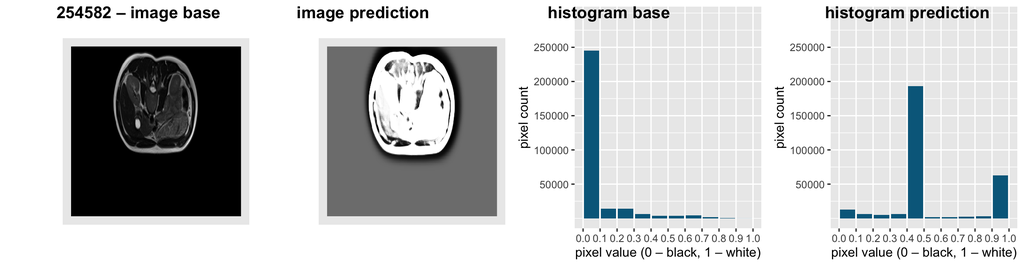

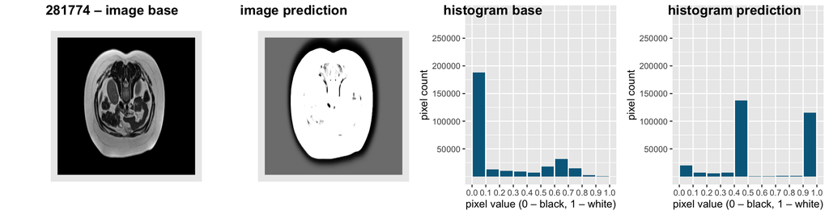

```r
make_4plots <- function(n, id, x_train, y_pred) {
  p1 <- plotColor(x_train[[1]])
  p2 <- plotColor(y_pred[[2]])
  p3 <- pixels_hist(x_train[[1]] / max(x_train[[1]]), NULL)
  p4 <- pixels_hist(y_pred[[2]], NULL)

  p <- cowplot::plot_grid(
    p1, p2, p3, p4,
    ncol = 4,
    align = "v",
    labels = c(stringr::str_c(id, " – image base"), "image prediction", "histogram base", "histogram prediction"),
    label_size = 14,
    label_x = -0.1
  )

  print(p)
}

purrr::pwalk(
  list(
    n = 1:training_batch_size,
    id = info$image_id,
    x_train = decodeUnet(X_train, domain_image),
    y_pred = Y_pred
  ),
  make_4plots
)
```